# Project 2: Analysis of Movies using IMDB Data

Group 8

2021-10-20

Analysis of movies- IMDB dataset

We will look at a subset sample of movies, taken from the [Kaggle IMDB 5000 movie dataset](https://www.kaggle.com/carolzhangdc/imdb-5000-movie-dataset)

```r
movies <- read_csv(here::here("data", "movies.csv"))
glimpse(movies)
```

```
## Rows: 2,961
## Columns: 11
## $ title               <chr> "Avatar", "Titanic", "Jurassic World", "The Avenge…
## $ genre               <chr> "Action", "Drama", "Action", "Action", "Action", "…
## $ director            <chr> "James Cameron", "James Cameron", "Colin Trevorrow…
## $ year                <dbl> 2009, 1997, 2015, 2012, 2008, 1999, 1977, 2015, 20…
## $ duration            <dbl> 178, 194, 124, 173, 152, 136, 125, 141, 164, 93, 1…
## $ gross               <dbl> 7.61e+08, 6.59e+08, 6.52e+08, 6.23e+08, 5.33e+08, …
## $ budget              <dbl> 2.37e+08, 2.00e+08, 1.50e+08, 2.20e+08, 1.85e+08, …
## $ cast_facebook_likes <dbl> 4834, 45223, 8458, 87697, 57802, 37723, 13485, 920…
## $ votes               <dbl> 886204, 793059, 418214, 995415, 1676169, 534658, 9…
## $ reviews             <dbl> 3777, 2843, 1934, 2425, 5312, 3917, 1752, 1752, 35…
## $ rating              <dbl> 7.9, 7.7, 7.0, 8.1, 9.0, 6.5, 8.7, 7.5, 8.5, 7.2, …
```

```r
skimr::skim(movies)
```

Data summary

| Name | movies |
| --- | --- |
| Number of rows | 2961 |
| Number of columns | 11 |
| _______________________ |  |
| Column type frequency: |  |
| character | 3 |
| numeric | 8 |
| ________________________ |  |
| Group variables | None |

**Variable type: character**

| skim_variable | n_missing | complete_rate | min | max | empty | n_unique | whitespace |
| --- | --- | --- | --- | --- | --- | --- | --- |
| title | 0 | 1 | 1 | 83 | 0 | 2907 | 0 |
| genre | 0 | 1 | 5 | 11 | 0 | 17 | 0 |
| director | 0 | 1 | 3 | 32 | 0 | 1366 | 0 |

**Variable type: numeric**

| skim_variable | n_missing | complete_rate | mean | sd | p0 | p25 | p50 | p75 | p100 | hist |
| --- | --- | --- | --- | --- | --- | --- | --- | --- | --- | --- |
| year | 0 | 1 | 2.00e+03 | 9.95e+00 | 1920.0 | 2.00e+03 | 2.00e+03 | 2.01e+03 | 2.02e+03 | ▁▁▁▂▇ |
| duration | 0 | 1 | 1.10e+02 | 2.22e+01 | 37.0 | 9.50e+01 | 1.06e+02 | 1.19e+02 | 3.30e+02 | ▃▇▁▁▁ |
| gross | 0 | 1 | 5.81e+07 | 7.25e+07 | 703.0 | 1.23e+07 | 3.47e+07 | 7.56e+07 | 7.61e+08 | ▇▁▁▁▁ |
| budget | 0 | 1 | 4.06e+07 | 4.37e+07 | 218.0 | 1.10e+07 | 2.60e+07 | 5.50e+07 | 3.00e+08 | ▇▂▁▁▁ |
| cast_facebook_likes | 0 | 1 | 1.24e+04 | 2.05e+04 | 0.0 | 2.24e+03 | 4.60e+03 | 1.69e+04 | 6.57e+05 | ▇▁▁▁▁ |
| votes | 0 | 1 | 1.09e+05 | 1.58e+05 | 5.0 | 1.99e+04 | 5.57e+04 | 1.33e+05 | 1.69e+06 | ▇▁▁▁▁ |
| reviews | 0 | 1 | 5.03e+02 | 4.94e+02 | 2.0 | 1.99e+02 | 3.64e+02 | 6.31e+02 | 5.31e+03 | ▇▁▁▁▁ |
| rating | 0 | 1 | 6.39e+00 | 1.05e+00 | 1.6 | 5.80e+00 | 6.50e+00 | 7.10e+00 | 9.30e+00 | ▁▁▆▇▁ |

Besides the obvious variables of `title`, `genre`, `director`, `year`, and `duration`, the rest of the variables are as follows:

- `gross` : The gross earnings in the US box office, not adjusted for inflation
- `budget`: The movie’s budget
- `cast_facebook_likes`: the number of facebook likes cast memebrs received
- `votes`: the number of people who voted for (or rated) the movie in IMDB
- `reviews`: the number of reviews for that movie
- `rating`: IMDB average rating

## 0.1 Use your data import, inspection, and cleaning skills to answer the following:

- Are there any missing values (NAs)? Are all entries distinct or are there duplicate entries? There are no missing values, but there are some duplicate entries. This is why we created the variable “unique_movies” to account for duplicates in analysing our data.
- Produce a table with the count of movies by genre, ranked in descending order

  ```r
  unique_movies <- movies %>%
    distinct(title,genre,director,year,.keep_all = TRUE)
  movies_count_genre<-unique_movies %>%
  group_by(genre) %>%
    count(sort=TRUE)

    head(movies_count_genre)
  ```

  ```
  ## # A tibble: 6 × 2
  ## # Groups:   genre [6]
  ##   genre         n
  ##   <chr>     <int>
  ## 1 Comedy      844
  ## 2 Action      719
  ## 3 Drama       484
  ## 4 Adventure   281
  ## 5 Crime       198
  ## 6 Biography   135
  ```

  Comment: Genres that cater to a wider crowd tend to have more demand and therefore more are produced (i.e. comedy and action films). Other genres such as crime, biography and drama tend to require more specific interests which cater to a smaller crowd and thus garner less demand.
- Produce a table with the average gross earning and budget (`gross` and `budget`) by genre. Calculate a variable `return_on_budget` which shows how many $ did a movie make at the box office for each $ of its budget. Ranked genres by this `return_on_budget` in descending order

  ```r
  returns_movies <- unique_movies %>%
    group_by(genre)%>%
    summarise(mean_gross = mean(gross),
              mean_budget = mean(budget)
              ) %>%
    mutate(return_on_budget = (mean_gross-mean_budget)/mean_budget) %>%
    arrange(-return_on_budget)
  head(returns_movies)
  ```

  ```
  ## # A tibble: 6 × 4
  ##   genre       mean_gross mean_budget return_on_budget
  ##   <chr>            <dbl>       <dbl>            <dbl>
  ## 1 Musical      92084000     3189500             27.9
  ## 2 Family      149160478.   14833333.             9.06
  ## 3 Western      20821884     3465000              5.01
  ## 4 Documentary  17353973.    5887852.             1.95
  ## 5 Horror       37782310.   13804379.             1.74
  ## 6 Fantasy      41902674.   18484615.             1.27
  ```

  Comment: Musicals have the highest return on budget by far. This is because their mean budget tends to be very low compared to horror and fantasy movies which have very high mean budgets because they require both special effects and live actors. Musicals also tend to exhibit many elements that family films also have which lets them draw in a wider audience.
- Produce a table that shows the top 15 directors who have created the highest gross revenue in the box office. Don’t just show the total gross amount, but also the mean, median, and standard deviation per director.

  ```r
  top_directors<- unique_movies %>%
    group_by(director) %>%
    summarise(
              sum_gross=sum(gross),
              mean_gross = mean(gross),
              median_gross = median(gross),
              sd_gross = sd(gross)) %>%
    arrange(desc(sum_gross))

  head(top_directors, 15)
  ```

  ```
  ## # A tibble: 15 × 5
  ##    director           sum_gross mean_gross median_gross   sd_gross
  ##    <chr>                  <dbl>      <dbl>        <dbl>      <dbl>
  ##  1 Steven Spielberg  4014061704 174524422.   164435221  101421051.
  ##  2 Michael Bay       2195443511 182953626.   168468240. 125789167.
  ##  3 James Cameron     1909725910 318287652.   175562880. 309171337.
  ##  4 Christopher Nolan 1813227576 226653447    196667606. 187224133.
  ##  5 George Lucas      1741418480 348283696    380262555  146193880.
  ##  6 Robert Zemeckis   1619309108 124562239.   100853835   91300279.
  ##  7 Tim Burton        1557078534 111219895.    69791834   99304293.
  ##  8 Sam Raimi         1443167519 180395940.   138480208  174705230.
  ##  9 Clint Eastwood    1378321100  72543216.    46700000   75487408.
  ## 10 Francis Lawrence  1358501971 271700394.   281666058  135437020.
  ## 11 Ron Howard        1335988092 111332341    101587923   81933761.
  ## 12 Gore Verbinski    1329600995 189942999.   123207194  154473822.
  ## 13 Andrew Adamson    1137446920 284361730    279680930. 120895765.
  ## 14 Shawn Levy        1129750988 102704635.    85463309   65484773.
  ## 15 Ridley Scott      1128857598  80632686.    47775715   68812285.
  ```

  Comment: Steven Spielberg has a much higher gross revenue than the other directors. This can be attributed to the fact that he directed many films which are part of bigger franchise: e.g. Jurassic Park, Indiana Jones and Jaws. James Cameron has a disproportionately high standard deviation as two of his films (Titanic and Avatar) have grossed much more revenue than his other films.
- Finally, ratings. Produce a table that describes how ratings are distributed by genre. We don’t want just the mean, but also, min, max, median, SD and some kind of a histogram or density graph that visually shows how ratings are distributed.

  ```r
  rating_distribution <- unique_movies %>%
    group_by(genre) %>%
    summarise(
              min_rating=min(rating),
              max_rating = max(rating),
              mean_rating = mean(rating),
              median_rating = median(rating),
              sd_rating = sd(rating))
   head(rating_distribution)
  ```

  ```
  ## # A tibble: 6 × 6
  ##   genre     min_rating max_rating mean_rating median_rating sd_rating
  ##   <chr>          <dbl>      <dbl>       <dbl>         <dbl>     <dbl>
  ## 1 Action           2.1        9          6.23           6.3     1.04
  ## 2 Adventure        2.3        8.6        6.51           6.6     1.11
  ## 3 Animation        4.5        8          6.65           6.9     0.968
  ## 4 Biography        4.5        8.9        7.11           7.2     0.760
  ## 5 Comedy           1.9        8.8        6.11           6.2     1.02
  ## 6 Crime            4.8        9.3        6.92           6.9     0.853
  ```

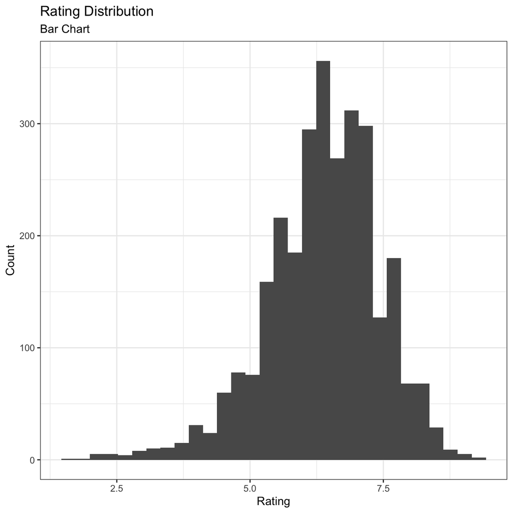

  ```r
  Rating_histogram <- ggplot(unique_movies, aes(x = rating)) +
    geom_histogram()+
    theme_bw()+
    labs(title = "Rating Distribution",
      subtitle = "Bar Chart",
      x = "Rating",
      y = "Count"
    )

  Rating_histogram
  ```

## 0.2 Use `ggplot` to answer the following

- Examine the relationship between `gross` and `cast_facebook_likes`. Produce a scatterplot and write one sentence discussing whether the number of facebook likes that the cast has received is likely to be a good predictor of how much money a movie will make at the box office. What variable are you going to map to the Y- and X- axes?

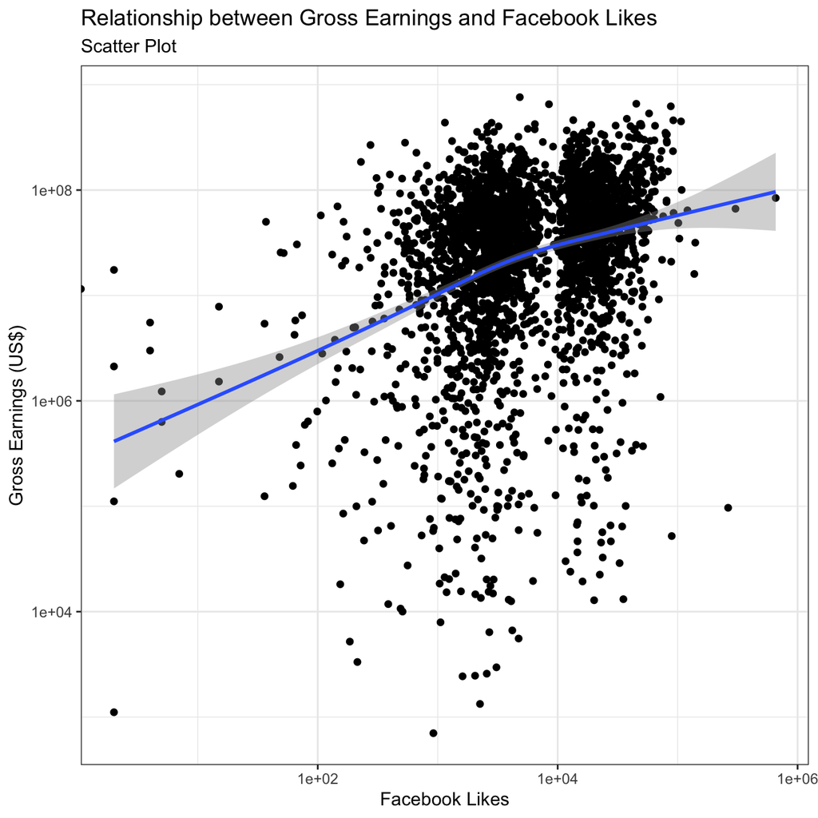

```r
ggplot(unique_movies, aes(y = gross, x = cast_facebook_likes)) +
  geom_point()+
  geom_smooth()+
   theme_bw()+
  labs(
    title = "Relationship between Gross Earnings and Facebook Likes",
    subtitle = "Scatter Plot",
    y = "Gross Earnings (US$)",
    x = "Facebook Likes"
  )+
    scale_y_log10()+
    scale_x_log10()+


  NULL
```

There is no strong positive relationship between gross earnings and Facebook likes. Having higher Facebook likes does not necessarily mean higher revenues as likes do not necessarily translate to people going out to spend money and watch the film. Nevertheless, the highest grossing films do tend to have quite a few Facebook likes as they are very popular. Our x-axis is Facebook likes and our y-axis is Gross Earnings because we are trying to test if Facebook likes is a good predictor of Gross Earnings.

- Examine the relationship between `gross` and `budget`. Produce a scatterplot and write one sentence discussing whether budget is likely to be a good predictor of how much money a movie will make at the box office.

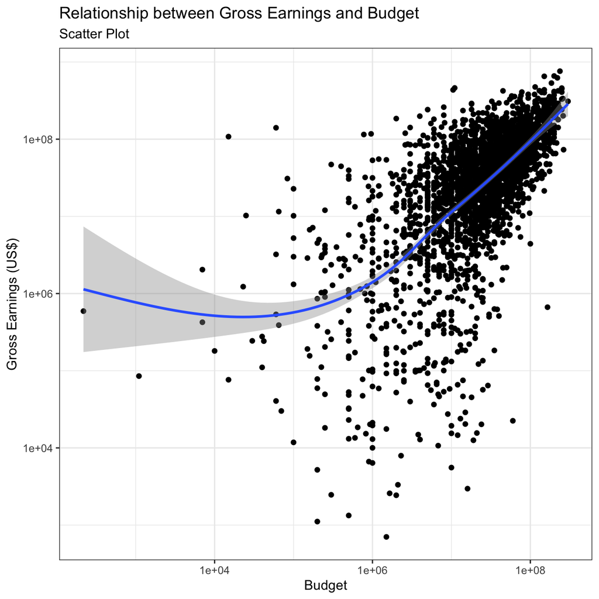

```r
ggplot(unique_movies, aes(y = gross, x = budget)) +
  geom_point()+
  geom_smooth()+
   theme_bw()+
  labs(
    title = "Relationship between Gross Earnings and Budget",
    subtitle = "Scatter Plot",
    y = "Gross Earnings (US$)",
    x = "Budget"
  )+
  scale_y_log10()+
  scale_x_log10()
```

```r
  NULL
```

There is not a strong positive correlation between gross earnings and budget, until the budget surpasses 1 million. After this point, there begins to be a stronger positive correlation. The sample size of films with a budget of less than 1 million is also very small. There are quite a few films with high budgets which flop at the box office, which shows why the correlation is not that strong.

- Examine the relationship between `gross` and `rating`. Produce a scatterplot, faceted by `genre` and discuss whether IMDB ratings are likely to be a good predictor of how much money a movie will make at the box office. Is there anything strange in this dataset?

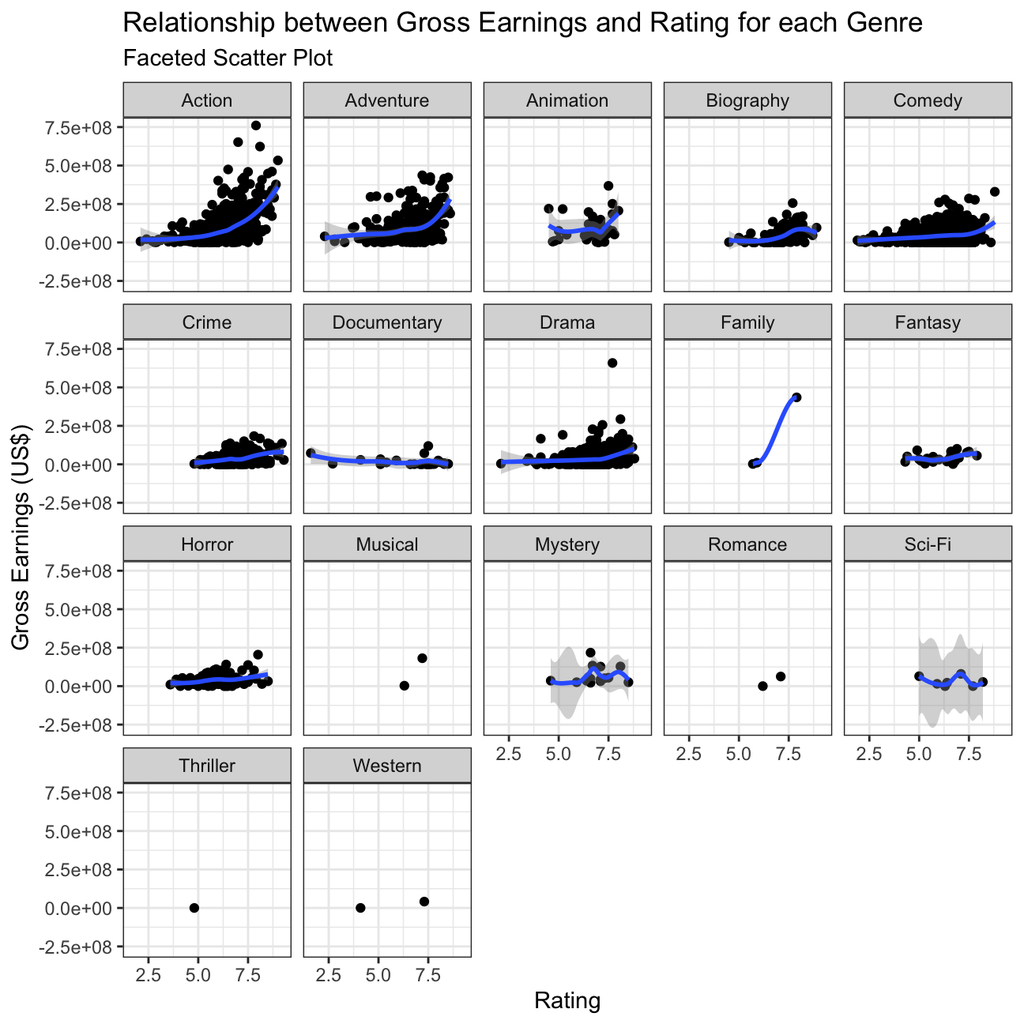

```r
ggplot(unique_movies, aes(x = rating, y = gross)) +
  geom_point()+
  facet_wrap(~genre)+
  geom_smooth()+
   theme_bw()+
  labs(
    title = "Relationship between Gross Earnings and Rating for each Genre",
    subtitle = "Faceted Scatter Plot",
    x = "Rating",
    y = "Gross Earnings (US$)"
  )+
  #scale_y_log10()+
  #scale_x_log10()

  NULL
```

There is less correlation between gross earnings and ratings for the comedy and horror genres because people often watch these types of films either to have a laugh or be scared regardless of the quality of the film or the plot. On the other hand, action and adventure films are more highly regarded based on the ratings they obtain as people watch these movies based on their perceived quality. Biography films also exhibit an interesting dynamic: there is a positive correlation between earnings and ratings until a certain point where it seems the highest rated biography films have lower earnings than expected. Similarly interesting patterns can be found in mystery and sci-fi films which peak in their earnings in the middle of their ratings distribution. However, these trends can also be explained by the small dataset.